# Assignment 4

## 1. Bayes theorem

$\mathbb P(A|B)=0.72/0.745$

## 2. Conditional probabilities

## 3. Sampling with replacement

$\binom{n}{k}=\frac{n!}{k!(n-k)!}$

Compute the numebr of subset of size 3 from a collection of size 8.

```r
choose(8,3)
```

```
[1] 56
```

Write a R function called prob_red_spheres() which takes z as an argument and computes the probability that z out of a total of the 35 balls selected are red.

```r
prob_red_sphere <- function(z) {
  p_red <- 3/10
  p_blue <- 1-p_red
  return (choose(35, z)*(p_red**z)*(p_blue**(35-z)))
}
```

```r
prob_red_sphere(20)
```

```
[1] 0.0005376555
```

Generate a data frame called **prob_by_num_reds** with two columns `num_reds` and `prob`. The `num_reds` column should contain number 1 through 35 and the `prob` column should give the associated probability of selecting that many reds out of a total number of 35 selections.

```r
prob_by_num_reds <- data.frame(num_reds=sequence(35))
```

```r
# Using tidyverse
library(tidyverse)
```

[figure not shown]

### Simulation

Simulate a random experiment in which we sample with replacement from a collection of 10 objects and repeat this process 35 times.

```r
sample(10, 35, replace=TRUE)
```

```
 [1]  3  3  3  6  6  5  5  3  7  1  5  1  5  4  6  7
[17]  5  8  2  8  1  2 10 10  1  3 10  2 10  4  8  1
[33]  7  4  4
```

```r
set.seed(0)

for(i in 1:5) {
  print(sample(100, 5, replace=FALSE))
}

print('----')
# Resetting the random seed every time.

for(i in 1:5) {
  set.seed(1)
  print(sample(100, 5, replace=FALSE))
}
```

[output not shown]

```r
num_trials<-1000 # set the number of trials set.seed(0) # set the random seed
set.seed(0)

sampling_with_replacement_simulation<-data.frame(trial=1:num_trials)%>% mutate(sample_balls=map(.x=trial,~sample(10,35,replace = TRUE)))
# generate collection of num_trials simulations

sampling_with_replacement_simulation
```

| trial | sample_balls |
| --- | --- |
| 1 |  |
| 2 |  |
| 3 |  |
| 4 |  |
| 5 |  |
| 6 |  |
| 7 |  |
| 8 |  |
| 9 |  |
| 10 |  |

[output cut: 990 more lines]

```r
# Add a new column called nums_reds contains an integer which gives the number of items within the sample for that row which are less than or equal to three.
sampling_with_replacement_simulation <- sampling_with_replacement_simulation %>% mutate(num_reds=map_dbl(.x=sample_balls, .f=~sum(.x <= 3)))
```

Next we shall add a new column called simulation_count to our existing data frame prob_by_num_reds which gives the number of times within our simulation we observed the corresponding number of reds. We can do this as follows:

```r
num_reds_in_simulation<-sampling_with_replacement_simulation%>%pull(num_reds) # we extract a vector corresponding to the number of reds in each trial
prob_by_num_reds <- prob_by_num_reds %>% mutate(simulation_count=map_dbl(.x=num_reds,~sum(num_reds_in_simulation==.x))) # add a column which gives the number of trials with a given number of reds
# count the number of num_reds in the all trials
```

[output not shown]

Next we add a column called expected_count corresponding to the expected number of observed reds in 1000 based upon your probability formula.

```r
prob_by_num_reds<-prob_by_num_reds%>% mutate(expected_count=num_trials*prob)
# add a column which gives the expected number of reds # based on the probability formula

prob_by_num_reds %>% head(5)
```

|  | num_reds | prob | simulation_count | expected_count |
| --- | --- | --- | --- | --- |
| 1 | 1 | 0.0000568228 | 0 | 0.0568228 |
| 2 | 2 | 0.0004139947 | 0 | 0.4139947 |
| 3 | 3 | 0.0019516894 | 3 | 1.9516894 |
| 4 | 4 | 0.0066915064 | 9 | 6.6915064 |
| 5 | 5 | 0.0177802884 | 16 | 17.7802884 |

Finally, create a plot which compares the results of your simulation with the expected count based on your probability formula. The concept of expectation will be discussed in Lecture 11.

Your result should look something like the plot below. Of course, since this is a random simulation, your result may well look slightly different.

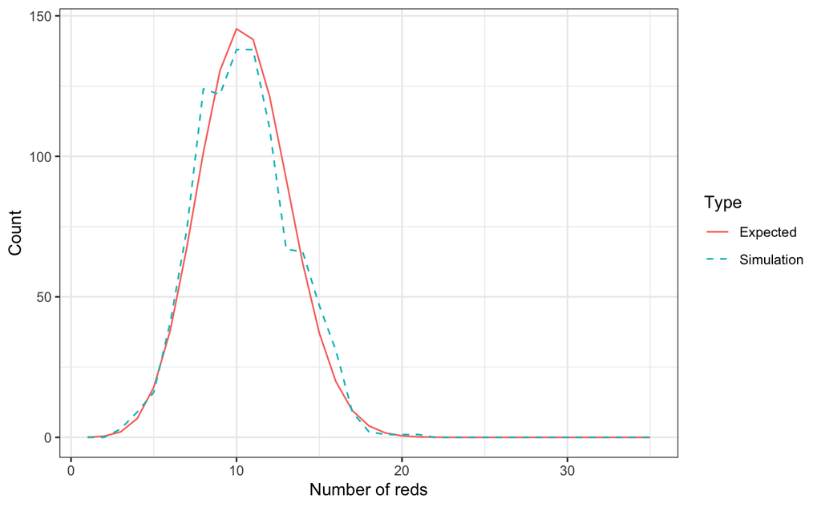

```r
prob_by_num_reds%>%
  rename(Simulation=simulation_count,Expected=expected_count)%>%
  pivot_longer(cols=c("Simulation","Expected"),
               names_to="Type",values_to="count")%>%
  ggplot(aes(num_reds,count)) +
    geom_line(aes(linetype=Type, color=Type)) +
    scale_linetype_manual(values = c("solid", "dashed"))+
  theme_bw()+
  xlab("Number of reds")+
  ylab("Count")
```

## 4. Sampling without replacement

In the last experiment, we have 10 balls of which 3 are reds and 7 are blues. Now we have 100 spheres, including 50 red spheres, 30 blue spheres and 20 green spheres. Suppose we sample 10 spheres from the bag **without** replacement.

```r
# Set a random seed
set.seed(0)

# Set number of trials, number of reds, blues and greens and sample size.
num_trials <- 10000
num_reds <- 50
num_blues <- 30
num_greens <- 20
sample_size <- 100

sample(100, 10, replace = FALSE)
```

```
 [1]  14  68  39   1  34  87  43 100  82  59
```

```r
# Simulating sample without placement
sampling_without_replacement_simulation <- data.frame(trial=1:num_trials) %>% mutate(sample_balls=map(.x=trial,~sample(100, 10, replace=FALSE)))

# Labeling and count number of colors
sampling_without_replacement_simulation <- sampling_without_replacement_simulation %>% mutate(num_reds=map_dbl(sample_balls, ~sum(.x<=num_reds)), num_blues=map_dbl(sample_balls, ~sum((num_reds<.x) & (.x <= num_reds+num_blues))), num_greens=map_dbl(sample_balls, ~sum((num_reds+num_blues<.x) & (.x<=num_reds+num_blues+num_greens))))

# Compute the minimum number of # of colors
sampling_without_replacement_simulation <- sampling_without_replacement_simulation %>% mutate(color_missing=pmin(num_reds, num_blues, num_greens)==0)

# Count the number of missing color trial
prob_missing_simulation <- mean(sampling_without_replacement_simulation %>% pull(color_missing))
prob_missing_simulation
```

[output not shown]

```r
set.seed(0) # set the random seed
num_trials<- 20000 # set the number of trials
n_red<-50
n_blue<-30
n_green<-20
sample_size<-10
total<-n_red+n_blue+n_green
sampling_without_replacement_simulation<-data.frame(trial=1:num_trials)%>% mutate(sample_balls=map(.x=trial,~sample(total,sample_size,replace = FALSE)))%>% # simulate without replacement the sampling of 10 balls from a bag of 100
mutate(num_reds=map_dbl(.x=sample_balls,~sum(.x<=n_red)))%>% mutate(num_blues=map_dbl(.x=sample_balls,~sum((n_red<.x)&(.x<=n_red+n_blue))))%>% mutate(num_greens=map_dbl(.x=sample_balls,~sum((n_red+n_blue<.x)&
                                                   (.x<=n_red+n_blue+n_green))))%>%
  mutate(colour_missing=(pmin(num_reds,num_blues,num_greens)==0))
  # look for missing colours
prob_missing_simulation<-mean(sampling_without_replacement_simulation%>%
                                pull(colour_missing))
prob_missing_simulation
```

```
[1] 0.11555
```

```r
sample_space = choose(100, 10)
events = choose(3, 1)*(1/3*choose(50, 10)+1/3*choose(70, 10)+1/3*choose(80, 10))-choose(3,2)*(1/3*choose(20, 10)+1/3*choose(50, 10)+1/3*choose(30, 10))
pro_without_placement = events / sample_space
print(pro_without_placement)
```

```
[1] 0.1180318
```